# BABIES teach vs. learn analyses

# Cell sizes

```r
d %>%
  distinct(ID, .keep_all = TRUE) %>%
  count(group)
```

| group | n |
| --- | --- |
| control | 22 |
| learn | 23 |
| teach | 21 |

```r
da %>%
  filter(group == "learn")
```

| ID | episode | sens_FP | intrus_FP | posreg_FP | stim_FP | negreg_FP | negmood_FP | posmood_FP | detach_FP | group | male | due_date | baby_dob | mom_dob | gestational_weeks_birth | baby_race | baby_race_describe | baby_latinx | mom_race | momrace_describe | mom_latinx | annual_income_num | annual_income_txt | ppl_in_home_tot_SClimit | education_txt | employment_status_txt | marital_status_txt | partner_educ_txt | partner_employ_txt | … |
| --- | --- | --- | --- | --- | --- | --- | --- | --- | --- | --- | --- | --- | --- | --- | --- | --- | --- | --- | --- | --- | --- | --- | --- | --- | --- | --- | --- | --- | --- | --- |
| 112 | 4 | 5.5 | 3.0 | 5.5 | 4.0 | 1.0 | 1.0 | 3.0 | 1.0 | learn | 0 | 2017-10-28 | 2017-10-22 | 1993-07-26 | 39.14286 | Other | Scottish, Mexican, Puerto Rican, Native American | 1 | Other | Half Mexican and Half Puerto Rican | 1 | 45000 | 30,001-60,000 | 91500 | Some college credit, no degree | Employed for wages | Single, never married | Some college credit, no degree | Employed for wages | … |
| 112 | 5 | 3.0 | 1.5 | 3.0 | 2.0 | 1.0 | 1.0 | 3.0 | 1.0 | learn | 0 | 2017-10-28 | 2017-10-22 | 1993-07-26 | 39.14286 | Other | Scottish, Mexican, Puerto Rican, Native American | 1 | Other | Half Mexican and Half Puerto Rican | 1 | 45000 | 30,001-60,000 | 91500 | Some college credit, no degree | Employed for wages | Single, never married | Some college credit, no degree | Employed for wages | … |
| 122 | 4 | 4.5 | 2.0 | 5.5 | 3.5 | 1.0 | 2.0 | 3.0 | 1.0 | learn | 0 | 2017-11-21 | 2017-11-21 | 1989-04-29 | 40.00000 | Asian | NA | 1 | Asian | NA | 0 | 150000 | >$150,000 | 76300 | Bachelor's degree | Employed for wages | Single, never married | NA | NA | … |
| 122 | 5 | 4.5 | 2.0 | 5.0 | 3.0 | 1.0 | 2.0 | 3.0 | 1.0 | learn | 0 | 2017-11-21 | 2017-11-21 | 1989-04-29 | 40.00000 | Asian | NA | 1 | Asian | NA | 0 | 150000 | >$150,000 | 76300 | Bachelor's degree | Employed for wages | Single, never married | NA | NA | … |
| 124 | 4 | 4.0 | 2.0 | 4.0 | 4.0 | 1.0 | 1.5 | 3.0 | 1.0 | learn | 1 | 2017-12-17 | 2017-12-19 | 1989-08-21 | 40.28571 | White | NA | 0 | White | NA | 0 | 120000 | 90,001-150,000 | 76300 | Bachelor's degree | Employed for wages | Married/domestic partnership | Bachelor's degree | Employed for wages | … |
| 124 | 5 | 3.0 | 1.0 | 3.0 | 2.0 | 1.0 | 1.0 | 3.0 | 1.0 | learn | 1 | 2017-12-17 | 2017-12-19 | 1989-08-21 | 40.28571 | White | NA | 0 | White | NA | 0 | 120000 | 90,001-150,000 | 76300 | Bachelor's degree | Employed for wages | Married/domestic partnership | Bachelor's degree | Employed for wages | … |
| 125 | 4 | 3.5 | 4.0 | 5.5 | 2.0 | 1.5 | 1.0 | 3.0 | 1.0 | learn | 1 | 2017-12-27 | 2018-01-08 | 1989-08-02 | 41.71429 | White | NA | 0 | White | NA | 0 | 150000 | >$150,000 | 76300 | Graduate degree | Employed for wages | Married/domestic partnership | Graduate degree | Employed for wages | … |
| 125 | 5 | 4.0 | 1.0 | 4.0 | 2.5 | 1.0 | 1.0 | 3.0 | 1.0 | learn | 1 | 2017-12-27 | 2018-01-08 | 1989-08-02 | 41.71429 | White | NA | 0 | White | NA | 0 | 150000 | >$150,000 | 76300 | Graduate degree | Employed for wages | Married/domestic partnership | Graduate degree | Employed for wages | … |
| 130 | 4 | 4.0 | 1.0 | 3.0 | 3.0 | 1.0 | 1.0 | 3.0 | 1.0 | learn | 0 | 2017-11-06 | 2017-10-29 | 1984-05-17 | 38.85714 | White | NA | 0 | White | NA | 0 | 150000 | >$150,000 | 84750 | Associate degree | Homemaker | Married/domestic partnership | Bachelor's degree | Employed for wages | … |
| 130 | 5 | 3.0 | 1.0 | 3.0 | 2.5 | 1.0 | 1.0 | 3.0 | 1.0 | learn | 0 | 2017-11-06 | 2017-10-29 | 1984-05-17 | 38.85714 | White | NA | 0 | White | NA | 0 | 150000 | >$150,000 | 84750 | Associate degree | Homemaker | Married/domestic partnership | Bachelor's degree | Employed for wages | … |

[output cut: 36 more lines]

# Examine missingness

```r
d_wf %>%
  count(is.na(mom_age))
```

| is.na(mom_age) | n |
| --- | --- |
| FALSE | 66 |

```r
d_wf %>%
  count(is.na(ppl_in_home_allchild))
```

| is.na(ppl_in_home_allchild) | n |
| --- | --- |
| FALSE | 66 |

```r
d_wf %>%
  count(is.na(education))
```

| is.na(education) | n |
| --- | --- |
| FALSE | 66 |

```r
d_wf %>%
  count(group, is.na(shipley_6mo_total))
```

| group | is.na(shipley_6mo_total) | n |
| --- | --- | --- |
| control | FALSE | 20 |
| control | TRUE | 2 |
| learn | FALSE | 23 |
| teach | FALSE | 19 |
| teach | TRUE | 2 |

```r
d_wf %>%
  count(group, is.na(cesd_total))
```

| group | is.na(cesd_total) | n |
| --- | --- | --- |
| control | FALSE | 22 |
| learn | FALSE | 23 |
| teach | FALSE | 21 |

```r
d_wf %>%
  count(group, is.na(crisys_total))
```

| group | is.na(crisys_total) | n |
| --- | --- | --- |
| control | FALSE | 19 |
| control | TRUE | 3 |
| learn | FALSE | 23 |
| teach | FALSE | 19 |
| teach | TRUE | 2 |

# Descriptive statistics

## Sample characteristics table

```r
d_sample_means <-
  d_wf %>%
  group_by(group) %>%
  summarise_at(
    vars(
      age_behav,
      mom_age,
      income_needs,
      cesd_total,
      crisys_total,

    ),
    funs(mean), na.rm = TRUE
  ) %>%
  gather(variable, mean, -group)

d_sample_sds <-
  d_wf %>%
  group_by(group) %>%
  summarise_at(
    vars(
      age_behav,
      mom_age,
      income_needs,
      cesd_total,
      crisys_total
    ),
    funs(sd), na.rm = TRUE
  ) %>%
  gather(variable, sd, -group)

d_sample_mins <-
  d_wf %>%
  group_by(group) %>%
  summarise_at(
    vars(
      age_behav,
      mom_age,
      income_needs,
      cesd_total,
      crisys_total
    ),
    funs(min), na.rm = TRUE
  ) %>%
  gather(variable, min, -group)

d_sample_maxs <-
  d_wf %>%
  group_by(group) %>%
  summarise_at(
    vars(
      age_behav,
      mom_age,
      income_needs,
      cesd_total,
      crisys_total,
    ),
    funs(max), na.rm = TRUE
  ) %>%
  gather(variable, max, -group)

d_sample_means %>%
  left_join(d_sample_sds, by = c("group", "variable")) %>%
  left_join(d_sample_mins, by = c("group", "variable"))  %>%
  left_join(d_sample_maxs, by = c("group", "variable")) %>%
  pivot_wider(
    names_from = group,
    values_from = mean:max
  )  %>%
  mutate_at(
    vars(mean_control:max_teach),
    funs(round(., 2))
  ) %>%
  mutate(
    mean_control = paste(mean_control, sd_control, sep = ", "),
    mean_teach = paste(mean_teach, sd_teach, sep = ", "),
    mean_learn = paste(mean_learn, sd_learn, sep = ", ")
  )
```

```r
d_wf %>%
  count(group, college_or_higher) %>%
  pivot_wider(
    names_from = group,
    values_from = n
  )
```

```r
d_wf %>%
  count(group, mom_race) %>%
  arrange(group, desc(n)) %>%
  pivot_wider(
    names_from = group,
    values_from = n
  )
```

```r
d_wf %>%
  count(group, mom_latinx) %>%
  pivot_wider(
    names_from = group,
    values_from = n
  )
```

```r
d_wf %>%
  count(group, male) %>%
  pivot_wider(
    names_from = group,
    values_from = n
  )
```

```r
d_wf %>%
  count(group, only_child) %>%
  pivot_wider(
    names_from = group,
    values_from = n
  )
```

## Reliability

### Covariates

```r
d_wf %>%
  dplyr::select(
    cesd_1:cesd_20
  ) %>%
  psych::alpha()

d_wf %>%
  dplyr::select(
    crisys_1:crisys_68
  ) %>%
  psych::alpha()
```

### Caregiving behavior

```r
#intrusiveness
fp_master %>%
  filter(Episode < 4) %>%
  dplyr::select(
    intrus_r1,
    intrus_r2
  ) %>%
  na.omit() %>%
  psych::ICC()
```

```r
#sensitivity
fp_master %>%
  filter(Episode < 4) %>%
  dplyr::select(
    sens_r1,
    sens_r2
  ) %>%
  na.omit() %>%
  psych::ICC()
```

```r
#stimulation
fp_master %>%
  filter(Episode < 4) %>%
  dplyr::select(
    stim_r1,
    stim_r2
  ) %>%
  na.omit() %>%
  psych::ICC()
```

```r
#positive regard
fp_master %>%
  filter(Episode < 4) %>%
  dplyr::select(
    posreg_r1,
    posreg_r2
  ) %>%
  na.omit() %>%
  psych::ICC()
```

```r
#negative regard
fp_master %>%
  filter(Episode < 4) %>%
  dplyr::select(
    negreg_r1,
    negreg_r2
  ) %>%
  na.omit() %>%
  psych::ICC()
```

```r
#detachment
fp_master %>%
  filter(Episode < 4) %>%
  dplyr::select(
    detach_r1,
    detach_r2
  ) %>%
  na.omit() %>%
  psych::ICC()
```

## Distributions of caregiving behaviors

```r
da %>%
  dplyr::select(
    group,
    episode_f,
    Intrusiveness = intrus_FP,
    Sensitivity = sens_FP,
    `Cog. stimulation` = stim_FP,
    `Positive regard` = posreg_FP,
    `Negative regard` = negreg_FP,
    Detachment = detach_FP
  ) %>%
  mutate(
     episode_f = recode_factor(
      episode_f,
      "4" = "Time 1",
      "5" = "Time 2"
    ),
    group = recode_factor(
      group,
      "control" = "Control",
      "teach" = "Teach",
      "learn" = "Learn"
    )
  ) %>%
  gather(
    key,
    value,
    Intrusiveness:Detachment
  ) %>%
  mutate(
    key = factor(
      key,
      levels = c(
        "Intrusiveness",
        "Sensitivity",
        "Cog. stimulation",
        "Positive regard",
        "Negative regard",
        "Detachment"
      )
    )
  ) %>%
  ggplot(aes(value, fill = group)) +
  geom_density(alpha = 1/2) +
  scale_fill_manual(values = cbbPalette) +
  theme_pubr() +
  theme(
    strip.text = element_text(size = 16),
    axis.title.y = element_text(size = 20),
    axis.title.x = element_text(size = 20),
    axis.text.y = element_text(size = 16),
    axis.text.x = element_text(size = 16),
    legend.title = element_text(size = 18),
    legend.text = element_text(size = 16),
    legend.position = "bottom"
  ) +
  labs(
    x = NULL,
    fill = "Group"
  ) +
  facet_grid(key~episode_f, scales = "free")


ggsave(
  "~/Box/lucy_king_files/BABIES/teach_learn/figures/group_caregiving_density_plots.png",
  dpi = 600,
  width = 7,
  height = 12
)
```

## Examine matching across groups

Variables examined: age, income-to-needs ratio, education, person of color, number of children, depressive symptoms, infant sex

### Distributions for continuous covariates

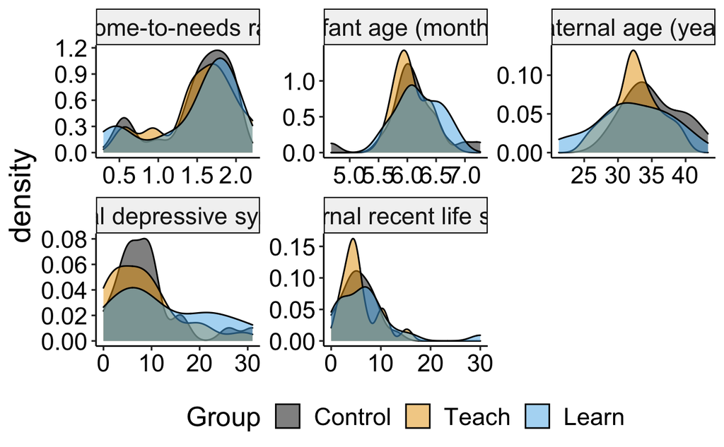

```r
d_wf %>%
  dplyr::select(
    group,
    `Infant age (months)` = age_behav,
    `Maternal age (years)` = mom_age,
    `Income-to-needs ratio` = income_needs,
    `Maternal depressive symptoms` = cesd_total,
    `Maternal recent life stress` = crisys_total
  ) %>%
  gather(
    key,
    value,
    -group
  ) %>%
  mutate(
    group = recode_factor(
      group,
      "control" = "Control",
      "teach" = "Teach",
      "learn" = "Learn"
    )
  ) %>%
  ggplot(aes(value, fill = group)) +
  geom_density(alpha = 1/2) +
  scale_fill_manual(values = cbbPalette) +
  theme_pubr() +
  theme(
    strip.text = element_text(size = 16),
    axis.title.y = element_text(size = 20),
    axis.title.x = element_text(size = 20),
    axis.text.y = element_text(size = 16),
    axis.text.x = element_text(size = 16),
    legend.title = element_text(size = 18),
    legend.text = element_text(size = 16),
    legend.position = "bottom"
  ) +
  labs(
    x = NULL,
    fill = "Group"
  ) +
  facet_wrap(.~key, scales = "free")


ggsave(
  "~/Box/lucy_king_files/BABIES/teach_learn/figures/group_matching_density_plots.png",
  dpi = 600,
  width = 12,
  height = 7
)
```

### Test differences

```r
chisq.test(d_wf$college_or_higher, d_wf$group)
```

```
Chi-squared approximation may be incorrect
```

```
    Pearson's Chi-squared test

data:  d_wf$college_or_higher and d_wf$group
X-squared = 4.8729, df = 2, p-value = 0.08747
```

# Test pre-registered hypotheses

We hypothesize that an instruction delivered after epoch 4 regarding the parent’s goal for epoch 5 will result in a change in maternal intrusiveness (relative to a control group with no instruction), such that, compared to epoch 4, a “teach” goal will result in increased intrusiveness during epoch 5 whereas a “learn” goal will result in decreased intrusiveness during epoch 5. We hypothesize no change in intrusiveness from epoch 4 to epoch 5 for the control (no instruction) group. Thus, we hypothesize that time (epoch 4, epoch 5) and group (control, teach, learn) will interact to explain variation in maternal intrusiveness.

## Dummy-code episode and group

```r
da <-
  da %>%
  mutate(
    episode_f = as.factor(episode),
    group = as.factor(group)
  )
```

## Omnibus interaction effect with control group as baseline

```r
contrasts(da$group) = cbind( # control group is baseline
  "learn" = c(0, 1, 0),
  "teach" = c(0, 0, 1)
)
contrasts(da$episode_f) # pre-treatment is baseline
```

```
  5
4 0
5 1
```

```r
mlm_h_c <-
  lmer(
    intrus_FP ~
      group * episode_f + (1|ID),
    data = da
  )

anova(mlm_h_c)
```

```
Type III Analysis of Variance Table with Satterthwaite's method
                Sum Sq Mean Sq NumDF DenDF F value   Pr(>F)
group           1.2586 0.62932     2    63  1.3222 0.273830
episode_f       0.9109 0.91093     1    63  1.9139 0.171410
group:episode_f 5.2578 2.62888     2    63  5.5235 0.006162 **
---
Signif. codes:  0 ‘***’ 0.001 ‘**’ 0.01 ‘*’ 0.05 ‘.’ 0.1 ‘ ’ 1
```

```r
model_parameters(
  mlm_h_c,
  standardize = "refit",
  df_method = "satterthwaite"
)
```

```
Parameter                     | Coefficient |   SE |        95% CI |     t |    df |     p
------------------------------------------------------------------------------------------
(Intercept)                   |       -0.03 | 0.21 | [-0.44, 0.38] | -0.16 | 90.23 | 0.876
group [learn]                 |       -0.06 | 0.29 | [-0.63, 0.52] | -0.19 | 90.23 | 0.850
group [teach]                 |       -0.04 | 0.30 | [-0.63, 0.55] | -0.14 | 90.23 | 0.888
episode_f [5]                 |        0.08 | 0.18 | [-0.28, 0.43] |  0.44 | 63.00 | 0.664
group [learn] * episode_f [5] |       -0.32 | 0.25 | [-0.82, 0.17] | -1.28 | 63.00 | 0.204
group [teach] * episode_f [5] |        0.52 | 0.26 | [ 0.01, 1.03] |  2.01 | 63.00 | 0.048
```

```r
performance(mlm_h_c)
```

```
# Indices of model performance

   AIC |    BIC | R2_conditional | R2_marginal |  ICC | RMSE | Sigma
--------------------------------------------------------------------
391.91 | 414.97 |           0.65 |        0.06 | 0.63 | 0.53 |  0.69
```

## learn group as baseline

```r
contrasts(da$group) = cbind( # learn group is baseline
  "control" = c(1, 0, 0),
  "teach" = c(0, 0, 1)
)

mlm_h_l <-
  lmer(
    intrus_FP ~
      group * episode_f + (1|ID),
    data = da
  )
summary(mlm_h_l)
```

```
Linear mixed model fit by REML. t-tests use Satterthwaite's method ['lmerModLmerTest']
Formula: intrus_FP ~ group * episode_f + (1 | ID)
   Data: da

REML criterion at convergence: 375.9

Scaled residuals:
    Min      1Q  Median      3Q     Max
-1.8942 -0.5906 -0.1640  0.5800  2.0446

Random effects:
 Groups   Name        Variance Std.Dev.
 ID       (Intercept) 0.8091   0.8995
 Residual             0.4759   0.6899
Number of obs: 132, groups:  ID, 66

Fixed effects:
                        Estimate Std. Error       df t value Pr(>|t|)
(Intercept)              2.41304    0.23637 90.23001  10.209  < 2e-16 ***
groupcontrol             0.06423    0.33806 90.23001   0.190  0.84974
groupteach               0.01553    0.34215 90.23001   0.045  0.96390
episode_f5              -0.28261    0.20344 63.00000  -1.389  0.16967
groupcontrol:episode_f5  0.37352    0.29095 63.00000   1.284  0.20393
groupteach:episode_f5    0.97308    0.29447 63.00000   3.304  0.00157 **
---
Signif. codes:  0 ‘***’ 0.001 ‘**’ 0.01 ‘*’ 0.05 ‘.’ 0.1 ‘ ’ 1

Correlation of Fixed Effects:
            (Intr) grpcnt grptch epsd_5 grpc:_5
groupcontrl -0.699
groupteach  -0.691  0.483
episode_f5  -0.430  0.301  0.297
grpcntrl:_5  0.301 -0.430 -0.208 -0.699
grptch:ps_5  0.297 -0.208 -0.430 -0.691  0.483
```

```r
parameters(
  mlm_h_l,
  standardize = "refit",
  df_method = "satterthwaite"
)
```

```
Parameter                       | Coefficient |   SE |        95% CI |     t |    df |     p
--------------------------------------------------------------------------------------------
(Intercept)                     |       -0.09 | 0.21 | [-0.49, 0.31] | -0.43 | 90.23 | 0.667
group [control]                 |        0.06 | 0.29 | [-0.52, 0.63] |  0.19 | 90.23 | 0.850
group [teach]                   |        0.01 | 0.30 | [-0.57, 0.60] |  0.05 | 90.23 | 0.964
episode_f [5]                   |       -0.25 | 0.18 | [-0.59, 0.10] | -1.39 | 63.00 | 0.170
group [control] * episode_f [5] |        0.32 | 0.25 | [-0.17, 0.82] |  1.28 | 63.00 | 0.204
group [teach] * episode_f [5]   |        0.85 | 0.26 | [ 0.34, 1.35] |  3.30 | 63.00 | 0.002
```

## teach group as baseline

```r
summary(mlm_h_t)
```

```
Linear mixed model fit by REML. t-tests use Satterthwaite's method ['lmerModLmerTest']
Formula: scale(intrus_FP, scale = TRUE) ~ group * episode_f + (1 | ID)
   Data: da

REML criterion at convergence: 340.5

Scaled residuals:
    Min      1Q  Median      3Q     Max
-1.8942 -0.5906 -0.1640  0.5800  2.0446

Random effects:
 Groups   Name        Variance Std.Dev.
 ID       (Intercept) 0.6110   0.7817
 Residual             0.3594   0.5995
Number of obs: 132, groups:  ID, 66

Fixed effects:
                        Estimate Std. Error       df t value Pr(>|t|)
(Intercept)             -0.07524    0.21497 90.23001  -0.350  0.72715
groupcontrol             0.04232    0.30054 90.23001   0.141  0.88833
grouplearn              -0.01349    0.29733 90.23001  -0.045  0.96390
episode_f5               0.60003    0.18502 63.00000   3.243  0.00189 **
groupcontrol:episode_f5 -0.52103    0.25866 63.00000  -2.014  0.04825 *
grouplearn:episode_f5   -0.84562    0.25590 63.00000  -3.304  0.00157 **
---
Signif. codes:  0 ‘***’ 0.001 ‘**’ 0.01 ‘*’ 0.05 ‘.’ 0.1 ‘ ’ 1

Correlation of Fixed Effects:
            (Intr) grpcnt grplrn epsd_5 grpc:_5
groupcontrl -0.715
grouplearn  -0.723  0.517
episode_f5  -0.430  0.308  0.311
grpcntrl:_5  0.308 -0.430 -0.223 -0.715
grplrn:ps_5  0.311 -0.223 -0.430 -0.723  0.517
```

Supporting our hypothesis, change in intrusiveness depended on group assignment. For the control group, there was no change in intrusiveness. For the learn group, there was a non-significant decrease in intrusiveness. For the teach group, there was a significant increase in intrusiveness.

## Visualize zero-order effects

```r
da_summary <-
  da %>%
  mutate(
    episode_f = recode_factor(
      episode_f,
      "4" = "Time 1",
      "5" = "Time 2"
    )
  ) %>%
  group_by(group, episode_f) %>%
  summarise(
    n = n(),
    Intrusiveness = mean(intrus_FP),
    intrus_sd = sd(intrus_FP),
    intrus_se = intrus_sd / sqrt(n),
    cog_stim = mean(stim_FP, na.rm = TRUE),
    cog_stim_sd = sd(stim_FP, na.rm = TRUE),
    cog_stim_se = cog_stim_sd / sqrt(n),
    posreg = mean(posreg_FP),
    posreg_sd = sd(posreg_FP),
    posreg_se = posreg_sd / sqrt(n)
  )
```

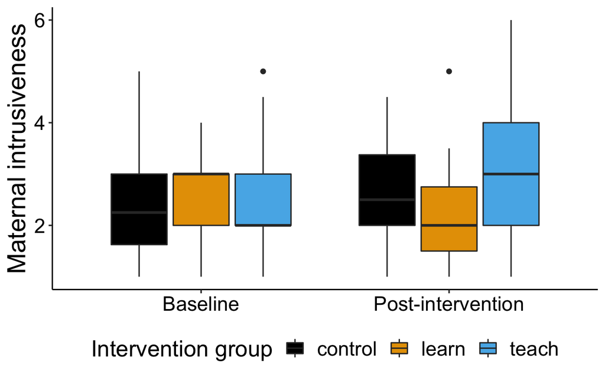

```r
da %>%
  mutate(
    episode_f = recode_factor(
      episode_f,
      "4" = "Baseline",
      "5" = "Post-intervention"
    )
  ) %>%
  ggplot(aes(episode_f, intrus_FP, fill = group)) +
  geom_boxplot() +
  scale_fill_manual(values = cbbPalette) +
  theme_pubr() +
  theme(
    strip.text = element_text(size = 16),
    axis.title.y = element_text(size = 20),
    axis.title.x = element_text(size = 20),
    axis.text.y = element_text(size = 16),
    axis.text.x = element_text(size = 16),
    legend.title = element_text(size = 18),
    legend.text = element_text(size = 16),
    legend.position = "bottom"
  ) +
  labs(
    x = NULL,
    y = "Maternal intrusiveness",
    fill = "Intervention group"
  )

ggsave(
  "~/Box/lucy_king_files/BABIES/teach_learn/figures/hypothesis_boxplot.png",
  dpi = 600,
  width = 7,
  height = 5
)
```

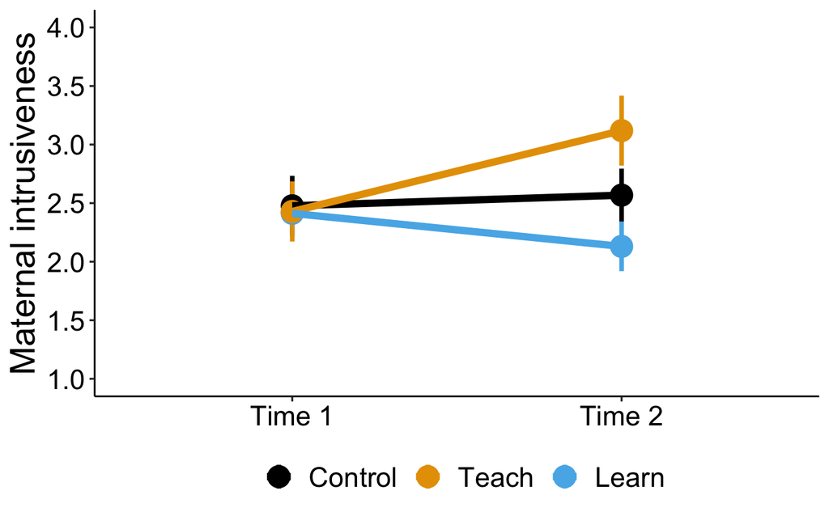

```r
gg_summary_p <-
  da_summary %>%
  mutate(
    group = recode_factor(
      group,
      "control" = "Control",
      "teach" = "Teach",
      "learn" = "Learn"
    )
  ) %>%
  ggplot(aes(episode_f, Intrusiveness, color = group))


gg_summary_p +
  geom_pointrange(
    aes(ymin = Intrusiveness - intrus_se, ymax = Intrusiveness + intrus_se),
    size = 1.25
  ) +
  geom_line(aes(group = group), size = 2) +
  scale_colour_manual(values=cbbPalette) +
  scale_y_continuous(breaks = seq.int(1, 7, .5), limits = c(1, 4)) +
  theme_pubr() +
  theme(
    strip.text = element_text(size = 16),
    axis.title.y = element_text(size = 20),
    axis.title.x = element_text(size = 20),
    axis.text.y = element_text(size = 16),
    axis.text.x = element_text(size = 16),
    legend.title = element_text(size = 18),
    legend.text = element_text(size = 16),
    legend.position = "bottom"
  ) +
  labs(
    x = NULL,
    y = "Maternal intrusiveness",
    color = NULL
  )

ggsave(
  "~/Box/lucy_king_files/BABIES/teach_learn/figures/hypothesis_lineplot.png",
  dpi = 600,
  width = 6,
  height = 5
)
```

## N (%) increased, descreased, etc.

| ID | group | 4 | 5 | intrus_diff | increased | decreased | stable |
| --- | --- | --- | --- | --- | --- | --- | --- |
| 112 | learn | 3 | 1.5 | -1.5 | FALSE | TRUE | FALSE |
| 124 | learn | 2 | 1.0 | -1.0 | FALSE | TRUE | FALSE |
| 125 | learn | 4 | 1.0 | -3.0 | FALSE | TRUE | FALSE |
| 1057 | learn | 4 | 3.0 | -1.0 | FALSE | TRUE | FALSE |
| 1063 | learn | 3 | 2.0 | -1.0 | FALSE | TRUE | FALSE |
| 1069 | learn | 3 | 2.0 | -1.0 | FALSE | TRUE | FALSE |
| 1104 | learn | 3 | 2.5 | -0.5 | FALSE | TRUE | FALSE |
| 1109 | learn | 3 | 1.5 | -1.5 | FALSE | TRUE | FALSE |
| 1111 | learn | 3 | 2.0 | -1.0 | FALSE | TRUE | FALSE |

# Additional analyses

## Covarying for infant sex and only child

```r
da <-
  da %>%
  mutate(
    male = as.factor(male)
  )
```

```r
contrasts(da$group) = cbind( # control group is baseline
  "learn" = c(0, 1, 0),
  "teach" = c(0, 0, 1)
)
contrasts(da$male) = c(-.5, .5) # effect code sex

mlm_h_c_planned_wf <-
  lmer(
    intrus_FP ~
      group * episode_f + (1|ID) +
      only_child +
      male,
    data = da
  )

anova(mlm_h_c_planned_wf)
```

```
Type III Analysis of Variance Table with Satterthwaite's method
                Sum Sq Mean Sq NumDF DenDF F value   Pr(>F)
group           1.2065 0.60323     2    61  1.2674 0.288861
episode_f       0.9109 0.91093     1    63  1.9139 0.171410
only_child      0.1282 0.12816     1    61  0.2693 0.605701
male            0.3115 0.31155     1    61  0.6546 0.421625
group:episode_f 5.2578 2.62888     2    63  5.5235 0.006162 **
---
Signif. codes:  0 ‘***’ 0.001 ‘**’ 0.01 ‘*’ 0.05 ‘.’ 0.1 ‘ ’ 1
```

```r
parameters(mlm_h_c_planned_wf, standardize = "refit")
```

```
Parameter                     | Coefficient |   SE |        95% CI | t(122) |     p
-----------------------------------------------------------------------------------
(Intercept)                   |       -0.08 | 0.25 | [-0.57, 0.40] |  -0.34 | 0.734
group [learn]                 |       -0.06 | 0.30 | [-0.64, 0.53] |  -0.19 | 0.846
group [teach]                 |       -0.05 | 0.30 | [-0.65, 0.55] |  -0.16 | 0.870
episode_f [5]                 |        0.08 | 0.18 | [-0.28, 0.43] |   0.44 | 0.662
only_child [only child]       |        0.12 | 0.22 | [-0.32, 0.55] |   0.52 | 0.604
male [1]                      |       -0.18 | 0.22 | [-0.62, 0.26] |  -0.81 | 0.418
group [learn] * episode_f [5] |       -0.32 | 0.25 | [-0.82, 0.17] |  -1.28 | 0.199
group [teach] * episode_f [5] |        0.52 | 0.26 | [ 0.01, 1.03] |   2.01 | 0.044
```

## Using all free play data

```r
d <-
  d %>%
  mutate(
    group = as.factor(group),
    male = as.factor(male),
    episode_pc = as.factor(
      case_when(
        episode == 1 ~ 0,
        episode == 2 ~ 0,
        episode == 3 ~ 0,
        episode == 4 ~ 0,
        episode == 5 ~ 1
      )
    )
  )
```

## Omnibus interaction effect with control group as baseline

```r
contrasts(d$group) = cbind( # control group is baseline
  "learn" = c(0, 1, 0),
  "teach" = c(0, 0, 1)
)
contrasts(d$episode_pc)
```

```
  1
0 0
1 1
```

```r
mlm_h_c_all <-
  lmer(
    intrus_FP ~
      group * episode_pc + (1|ID),
    data = d
  )
anova(mlm_h_c_all)
```

```
Type III Analysis of Variance Table with Satterthwaite's method
                 Sum Sq Mean Sq NumDF   DenDF F value   Pr(>F)
group            2.9236  1.4618     2  73.076  2.7567 0.070112 .
episode_pc       5.4444  5.4444     1 261.000 10.2671 0.001523 **
group:episode_pc 5.2045  2.6022     2 261.000  4.9073 0.008089 **
---
Signif. codes:  0 ‘***’ 0.001 ‘**’ 0.01 ‘*’ 0.05 ‘.’ 0.1 ‘ ’ 1
```

```r
parameters(mlm_h_c_all)
```

```
Parameter                      | Coefficient |   SE |        95% CI | t(322) |      p
-------------------------------------------------------------------------------------
(Intercept)                    |        2.43 | 0.19 | [ 2.06, 2.80] |  12.81 | < .001
group [learn]                  |       -0.36 | 0.27 | [-0.88, 0.16] |  -1.36 | 0.174
group [teach]                  |       -0.08 | 0.27 | [-0.61, 0.45] |  -0.30 | 0.767
episode_pc [1]                 |        0.14 | 0.17 | [-0.20, 0.48] |   0.79 | 0.432
group [learn] * episode_pc [1] |       -0.08 | 0.24 | [-0.55, 0.40] |  -0.32 | 0.752
group [teach] * episode_pc [1] |        0.63 | 0.25 | [ 0.14, 1.12] |   2.54 | 0.011
```

```r
performance(mlm_h_c_all)
```

```
# Indices of model performance

   AIC |    BIC | R2_conditional | R2_marginal |  ICC | RMSE | Sigma
--------------------------------------------------------------------
877.28 | 907.67 |           0.58 |        0.05 | 0.56 | 0.66 |  0.73
```

## learn group as baseline

```r
contrasts(d$group) = cbind( # learn group is baseline
  "control" = c(1, 0, 0),
  "teach" = c(0, 0, 1)
)

mlm_h_l_all <-
  lmer(
    intrus_FP ~
      group * episode_pc + (1|ID),
    data = d
  )
summary(mlm_h_l_all)
```

```
Linear mixed model fit by REML. t-tests use Satterthwaite's method ['lmerModLmerTest']
Formula: intrus_FP ~ group * episode_pc + (1 | ID)
   Data: d

REML criterion at convergence: 861.3

Scaled residuals:
     Min       1Q   Median       3Q      Max
-2.36966 -0.56764 -0.08481  0.49707  2.95946

Random effects:
 Groups   Name        Variance Std.Dev.
 ID       (Intercept) 0.6609   0.8129
 Residual             0.5303   0.7282
Number of obs: 330, groups:  ID, 66

Fixed effects:
                          Estimate Std. Error        df t value Pr(>|t|)
(Intercept)                2.07065    0.18573  67.41189  11.149  < 2e-16 ***
groupcontrol               0.36117    0.26564  67.41189   1.360  0.17848
groupteach                 0.28054    0.26885  67.41189   1.043  0.30045
episode_pc1                0.05978    0.16976 261.00000   0.352  0.72501
groupcontrol:episode_pc1   0.07658    0.24279 261.00000   0.315  0.75270
groupteach:episode_pc1     0.70807    0.24573 261.00000   2.882  0.00429 **
---
Signif. codes:  0 ‘***’ 0.001 ‘**’ 0.01 ‘*’ 0.05 ‘.’ 0.1 ‘ ’ 1

Correlation of Fixed Effects:
            (Intr) grpcnt grptch epsd_1 grpc:_1
groupcontrl -0.699
groupteach  -0.691  0.483
episode_pc1 -0.183  0.128  0.126
grpcntrl:_1  0.128 -0.183 -0.088 -0.699
grptch:ps_1  0.126 -0.088 -0.183 -0.691  0.483
```

```r
parameters(mlm_h_l_all)
```

```
Parameter                        | Coefficient |   SE |        95% CI | t(322) |      p
---------------------------------------------------------------------------------------
(Intercept)                      |        2.07 | 0.19 | [ 1.71, 2.43] |  11.15 | < .001
group [control]                  |        0.36 | 0.27 | [-0.16, 0.88] |   1.36 | 0.174
group [teach]                    |        0.28 | 0.27 | [-0.25, 0.81] |   1.04 | 0.297
episode_pc [1]                   |        0.06 | 0.17 | [-0.27, 0.39] |   0.35 | 0.725
group [control] * episode_pc [1] |        0.08 | 0.24 | [-0.40, 0.55] |   0.32 | 0.752
group [teach] * episode_pc [1]   |        0.71 | 0.25 | [ 0.23, 1.19] |   2.88 | 0.004
```

## teach group as baseline

```r
contrasts(d$group) = cbind( # teach group is baseline
  "control" = c(1, 0, 0),
  "learn" = c(0, 1, 0)
)

mlm_h_t_all <-
  lmer(
    intrus_FP ~
      group * episode_pc + (1|ID),
    data = d
  )
parameters(mlm_h_t_all)
```

```
Parameter                        | Coefficient |   SE |         95% CI | t(322) |      p
----------------------------------------------------------------------------------------
(Intercept)                      |        2.35 | 0.19 | [ 1.97,  2.73] |  12.10 | < .001
group [control]                  |        0.08 | 0.27 | [-0.45,  0.61] |   0.30 | 0.767
group [learn]                    |       -0.28 | 0.27 | [-0.81,  0.25] |  -1.04 | 0.297
episode_pc [1]                   |        0.77 | 0.18 | [ 0.42,  1.12] |   4.32 | < .001
group [control] * episode_pc [1] |       -0.63 | 0.25 | [-1.12, -0.14] |  -2.54 | 0.011
group [learn] * episode_pc [1]   |       -0.71 | 0.25 | [-1.19, -0.23] |  -2.88 | 0.004
```

## Other caregiving behaviors

### Correlations

```r
da_time_1 <-
  da %>%
  filter(episode == "4")

da_time_2 <-
  da %>%
  filter(episode == "5")

da_time_1 %>%
  select(stim_FP, education, income_needs) %>%
  correlate() %>%
  shave(upper = FALSE) %>%
  fashion()

da_time_2 %>%
  select(stim_FP, education, income_needs) %>%
  correlate() %>%
  shave(upper = FALSE) %>%
  fashion()
```

### Sensitivity

```r
contrasts(da$group) = cbind( # control group is baseline
  "learn" = c(0, 1, 0),
  "teach" = c(0, 0, 1)
)
contrasts(da$episode_f) # pre-treatment is baseline
```

```
  5
4 0
5 1
```

```r
mlm_sens_c <-
  lmer(
    sens_FP ~
      group * episode + (1|ID),
    data = da
  )

anova(mlm_sens_c)
```

```
Type III Analysis of Variance Table with Satterthwaite's method
                Sum Sq  Mean Sq NumDF DenDF F value Pr(>F)
group         0.014173 0.007087     2 68.22  0.0220 0.9783
episode       0.235357 0.235357     1 63.00  0.7290 0.3964
group:episode 0.056759 0.028380     2 63.00  0.0879 0.9160
```

```r
parameters(mlm_sens_c)
```

```
Parameter               | Coefficient |   SE |        95% CI | t(124) |      p
------------------------------------------------------------------------------
(Intercept)             |        4.07 | 0.79 | [ 2.53, 5.61] |   5.17 | < .001
group [learn]           |       -0.13 | 1.10 | [-2.29, 2.02] |  -0.12 | 0.904
group [teach]           |        0.10 | 1.13 | [-2.11, 2.31] |   0.09 | 0.930
episode                 |       -0.05 | 0.17 | [-0.38, 0.29] |  -0.27 | 0.791
group [learn] * episode |       -0.02 | 0.24 | [-0.49, 0.45] |  -0.08 | 0.934
group [teach] * episode |       -0.10 | 0.25 | [-0.58, 0.38] |  -0.40 | 0.691
```

### Warmth

```r
contrasts(da$group) = cbind( # control group is baseline
  "learn" = c(0, 1, 0),
  "teach" = c(0, 0, 1)
)

mlm_posreg_c <-
  lmer(
    posreg_FP ~
      group * episode + (1|ID),
    data = da
  )

anova(mlm_posreg_c)
```

```
Type III Analysis of Variance Table with Satterthwaite's method
               Sum Sq Mean Sq NumDF  DenDF F value  Pr(>F)
group         1.44854 0.72427     2 69.208  2.3607 0.10191
episode       0.62227 0.62227     1 63.000  2.0282 0.15933
group:episode 2.11258 1.05629     2 63.000  3.4429 0.03811 *
---
Signif. codes:  0 ‘***’ 0.001 ‘**’ 0.01 ‘*’ 0.05 ‘.’ 0.1 ‘ ’ 1
```

```r
parameters(mlm_posreg_c, standardize = "refit")
```

```
Parameter               | Coefficient |   SE |         95% CI | t(124) |     p
------------------------------------------------------------------------------
(Intercept)             |        0.43 | 0.18 | [ 0.07,  0.79] |   2.36 | 0.018
group [learn]           |       -0.63 | 0.26 | [-1.13, -0.13] |  -2.48 | 0.013
group [teach]           |       -0.66 | 0.26 | [-1.17, -0.15] |  -2.52 | 0.012
episode                 |        0.06 | 0.09 | [-0.12,  0.24] |   0.68 | 0.496
group [learn] * episode |       -0.32 | 0.13 | [-0.58, -0.07] |  -2.53 | 0.011
group [teach] * episode |       -0.09 | 0.13 | [-0.35,  0.17] |  -0.67 | 0.500
```

```r
performance(mlm_posreg_c)
```

```
# Indices of model performance

   AIC |    BIC | R2_conditional | R2_marginal |  ICC | RMSE | Sigma
--------------------------------------------------------------------
330.58 | 353.65 |           0.65 |        0.12 | 0.60 | 0.43 |  0.55
```

```r
contrasts(da$group) = cbind( # learn group is baseline
  "control" = c(1, 0, 0),
  "teach" = c(0, 0, 1)
)

mlm_posreg_l <-
  lmer(
    posreg_FP ~
      group * episode + (1|ID),
    data = da
  )

parameters(mlm_posreg_l, standardize = "refit")
```

```r
contrasts(da$group) = cbind( # teach group is baseline
  "control" = c(1, 0, 0),
  "learn" = c(0, 1, 0)
)

mlm_posreg_t <-
  lmer(
    posreg_FP ~
      group * episode + (1|ID),
    data = da
  )

parameters(mlm_posreg_t, standardize = "refit")
```

#### Visualize

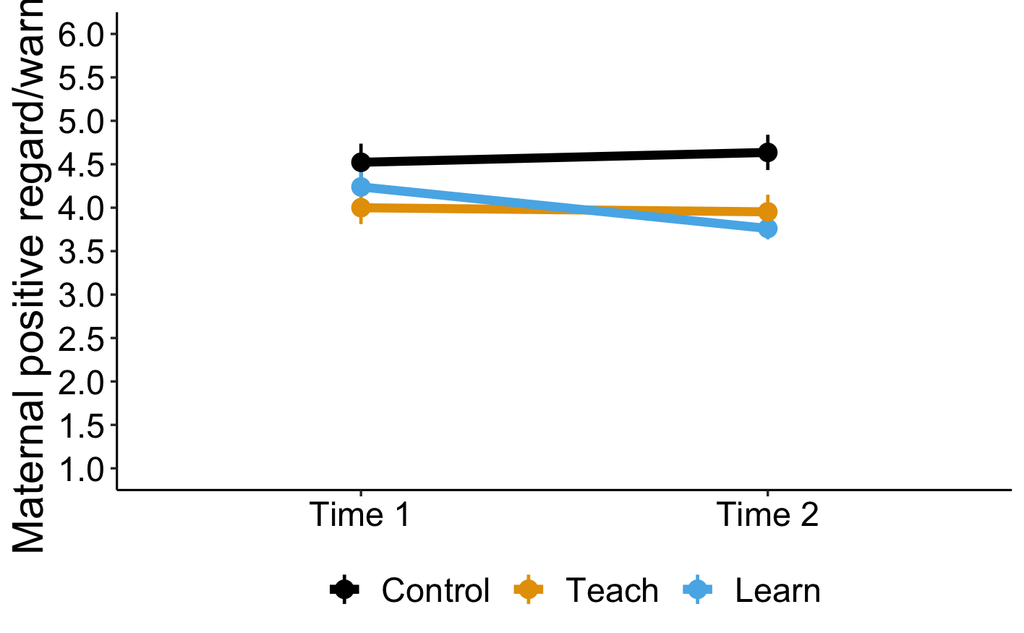

```r
gg_summary_p_posreg <-
  da_summary %>%
  mutate(
    group = recode_factor(
      group,
      "control" = "Control",
      "teach" = "Teach",
      "learn" = "Learn"
    )
  ) %>%
  ggplot(aes(episode_f, posreg, color = group))


gg_summary_p_posreg +
  geom_pointrange(
    aes(ymin = posreg - posreg_se, ymax = posreg + posreg_se),
    size = .75
  ) +
  geom_line(aes(group = group), size = 2) +
  scale_colour_manual(values=cbbPalette) +
  scale_y_continuous(breaks = seq.int(1, 7, .5), limits = c(1, 6)) +
  theme_pubr() +
  theme(
    strip.text = element_text(size = 16),
    axis.title.y = element_text(size = 20),
    axis.title.x = element_text(size = 20),
    axis.text.y = element_text(size = 16),
    axis.text.x = element_text(size = 16),
    legend.title = element_text(size = 18),
    legend.text = element_text(size = 16),
    legend.position = "bottom"
  ) +
  labs(
    x = NULL,
    y = "Maternal positive regard/warmth",
    color = NULL
  )

ggsave(
  "~/Box/lucy_king_files/BABIES/teach_learn/figures/lineplot_posreg.png",
  dpi = 600,
  width = 6,
  height = 5
)
```

### Cognitive stimulation

```r
contrasts(da$group) = cbind( # control group is baseline
  "learn" = c(0, 1, 0),
  "teach" = c(0, 0, 1)
)

mlm_stim_c <-
  lmer(
    stim_FP ~
      group * episode + (1|ID),
    data = da
  )

anova(mlm_stim_c)
```

```
Type III Analysis of Variance Table with Satterthwaite's method
              Sum Sq Mean Sq NumDF  DenDF F value    Pr(>F)
group         6.5757  3.2879     2 65.037 10.8439 8.625e-05 ***
episode       0.0129  0.0129     1 60.787  0.0426    0.8372
group:episode 8.0314  4.0157     2 60.792 13.2445 1.681e-05 ***
---
Signif. codes:  0 ‘***’ 0.001 ‘**’ 0.01 ‘*’ 0.05 ‘.’ 0.1 ‘ ’ 1
```

```r
parameters(mlm_stim_c, standardize = "refit")
```

```
Parameter               | Coefficient |   SE |         95% CI | t(120) |      p
-------------------------------------------------------------------------------
(Intercept)             |       -0.06 | 0.18 | [-0.41,  0.29] |  -0.33 | 0.741
group [learn]           |       -0.19 | 0.25 | [-0.67,  0.30] |  -0.76 | 0.448
group [teach]           |        0.37 | 0.25 | [-0.13,  0.86] |   1.46 | 0.145
episode                 |       -0.21 | 0.10 | [-0.41,  0.00] |  -1.96 | 0.050
group [learn] * episode |       -0.05 | 0.15 | [-0.34,  0.24] |  -0.35 | 0.724
group [teach] * episode |        0.63 | 0.15 | [ 0.34,  0.92] |   4.26 | < .001
```

```r
performance(mlm_stim_c)
```

```
# Indices of model performance

   AIC |    BIC | R2_conditional | R2_marginal |  ICC | RMSE | Sigma
--------------------------------------------------------------------
299.87 | 322.69 |           0.56 |        0.14 | 0.48 | 0.44 |  0.55
```

```r
contrasts(da$group) = cbind( # learn group is baseline
  "control" = c(1, 0, 0),
  "teach" = c(0, 0, 1)
)

mlm_stim_l <-
  lmer(
    stim_FP ~
      group * episode + (1|ID),
    data = da
  )

parameters(mlm_stim_l, standardize = "refit")
```

```r
contrasts(da$group) = cbind( # teach group is baseline
  "control" = c(1, 0, 0),
  "learn" = c(0, 1, 0)
)

mlm_stim_t <-
  lmer(
    stim_FP ~
      group * episode + (1|ID),
    data = da
  )

parameters(mlm_stim_t)
```

#### Visualize

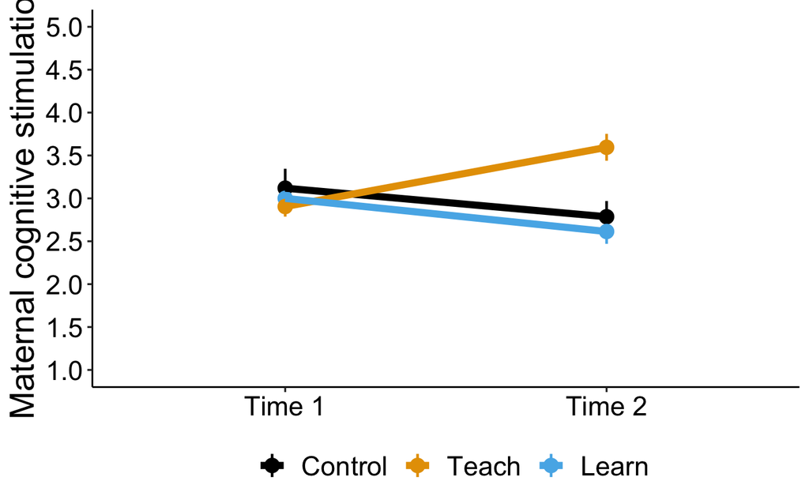

```r
gg_summary_p_stim <-
  da_summary %>%
  mutate(
    group = recode_factor(
      group,
      "control" = "Control",
      "teach" = "Teach",
      "learn" = "Learn"
    )
  ) %>%
  ggplot(aes(episode_f, cog_stim, color = group))


gg_summary_p_stim +
  geom_pointrange(
    aes(ymin = cog_stim - cog_stim_se, ymax = cog_stim + cog_stim_se),
    size = .75
  ) +
  geom_line(aes(group = group), size = 2) +
  scale_colour_manual(values=cbbPalette) +
  scale_y_continuous(breaks = seq.int(1, 7, .5), limits = c(1, 5)) +
  theme_pubr() +
  theme(
    strip.text = element_text(size = 16),
    axis.title.y = element_text(size = 20),
    axis.title.x = element_text(size = 20),
    axis.text.y = element_text(size = 16),
    axis.text.x = element_text(size = 16),
    legend.title = element_text(size = 18),
    legend.text = element_text(size = 16),
    legend.position = "bottom"
  ) +
  labs(
    x = NULL,
    y = "Maternal cognitive stimulation",
    color = NULL
  )

ggsave(
  "~/Box/lucy_king_files/BABIES/teach_learn/figures/lineplot_stim.png",
  dpi = 600,
  width = 6,
  height = 5
)
```

### Negative Regard

```r
contrasts(da$group) = cbind( # control group is baseline
  "learn" = c(0, 1, 0),
  "teach" = c(0, 0, 1)
)

mlm_negreg_c <-
  lmer(
    negreg_FP ~
      group * episode + (1|ID),
    data = da
  )

anova(mlm_negreg_c)
```

```
Type III Analysis of Variance Table with Satterthwaite's method
                Sum Sq  Mean Sq NumDF  DenDF F value Pr(>F)
group         0.038035 0.019018     2 65.895  0.8448 0.4343
episode       0.033146 0.033146     1 63.000  1.4724 0.2295
group:episode 0.051430 0.025715     2 63.000  1.1423 0.3256
```

### Detachment

```r
contrasts(da$group) = cbind( # control group is baseline
  "learn" = c(0, 1, 0),
  "teach" = c(0, 0, 1)
)

mlm_detach_c <-
  lmer(
    detach_FP ~
      group * episode + (1|ID),
    data = da
  )

anova(mlm_detach_c)
```

```
Type III Analysis of Variance Table with Satterthwaite's method
               Sum Sq Mean Sq NumDF  DenDF F value  Pr(>F)
group         0.45144 0.22572     2 68.292  0.7957 0.45541
episode       1.58902 1.58902     1 63.000  5.6014 0.02103 *
group:episode 0.16033 0.08016     2 63.000  0.2826 0.75479
---
Signif. codes:  0 ‘***’ 0.001 ‘**’ 0.01 ‘*’ 0.05 ‘.’ 0.1 ‘ ’ 1
```

### Infant negative mood

```r
contrasts(da$group) = cbind( # control group is baseline
  "learn" = c(0, 1, 0),
  "teach" = c(0, 0, 1)
)

mlm_negmood_c <-
  lmer(
    negmood_FP ~
      group * episode + (1|ID),
    data = da
  )

anova(mlm_negmood_c)
```

```
Type III Analysis of Variance Table with Satterthwaite's method
                Sum Sq  Mean Sq NumDF  DenDF F value Pr(>F)
group         0.067460 0.033730     2 64.661  0.0890 0.9150
episode       0.001239 0.001239     1 63.000  0.0033 0.9546
group:episode 0.235390 0.117695     2 63.000  0.3104 0.7343
```

### Infant positive mood

```r
contrasts(da$group) = cbind( # control group is baseline
  "learn" = c(0, 1, 0),
  "teach" = c(0, 0, 1)
)

mlm_posmood_c <-
  lmer(
    posmood_FP ~
      group * episode + (1|ID),
    data = da
  )

anova(mlm_posmood_c)
```

```
Type III Analysis of Variance Table with Satterthwaite's method
               Sum Sq  Mean Sq NumDF  DenDF F value Pr(>F)
group         0.19486 0.097428     2 65.328  0.5345 0.5885
episode       0.22722 0.227217     1 63.000  1.2465 0.2685
group:episode 0.16216 0.081081     2 63.000  0.4448 0.6429
```

### Covarying for cognitive stimulation and warmth

```r
da <-
  da %>%
  group_by(ID) %>%
  mutate(
    stim_FP_mean = mean(stim_FP, na.rm = TRUE),
    stim_FP_pc = stim_FP - stim_FP_mean,
    posreg_FP_mean = mean(posreg_FP),
    posreg_FP_pc = posreg_FP - posreg_FP_mean,
    intrus_FP_mean = mean (intrus_FP, na.rm = TRUE),
    intrus_FP_pc = intrus_FP - intrus_FP_mean
  ) %>%
  ungroup()
```

#### Cognitive stimulation

```r
contrasts(da$group) = cbind( # control group is baseline
  "learn" = c(0, 1, 0),
  "teach" = c(0, 0, 1)
)

mlm_h_c_stim <-
  lmer(
    intrus_FP ~
      group * episode_f +
      stim_FP_mean +
      stim_FP_pc +
      (1|ID),
    data = da
  )
anova(mlm_h_c_stim)
```

```
Type III Analysis of Variance Table with Satterthwaite's method
                Sum Sq Mean Sq NumDF  DenDF F value   Pr(>F)
group           1.7660 0.88298     2 60.581  1.8506 0.165911
episode_f       0.5646 0.56456     1 59.449  1.1833 0.281085
stim_FP_mean    0.9239 0.92387     1 60.621  1.9363 0.169153
stim_FP_pc      0.7151 0.71514     1 59.066  1.4989 0.225706
group:episode_f 5.9318 2.96592     2 59.521  6.2163 0.003534 **
---
Signif. codes:  0 ‘***’ 0.001 ‘**’ 0.01 ‘*’ 0.05 ‘.’ 0.1 ‘ ’ 1
```

```r
parameters(mlm_h_c_stim, standardize = "refit")
```

```
Parameter                     | Coefficient |   SE |        95% CI | t(118) |     p
-----------------------------------------------------------------------------------
(Intercept)                   |        0.02 | 0.22 | [-0.40, 0.44] |   0.10 | 0.921
group [learn]                 |       -0.12 | 0.30 | [-0.71, 0.47] |  -0.40 | 0.688
group [teach]                 |       -0.12 | 0.32 | [-0.74, 0.50] |  -0.38 | 0.703
episode_f [5]                 |       -0.02 | 0.19 | [-0.39, 0.36] |  -0.08 | 0.933
stim_FP_mean                  |       -0.16 | 0.11 | [-0.39, 0.07] |  -1.39 | 0.164
stim_FP_pc                    |       -0.08 | 0.06 | [-0.20, 0.05] |  -1.22 | 0.221
group [learn] * episode_f [5] |       -0.34 | 0.26 | [-0.85, 0.17] |  -1.30 | 0.195
group [teach] * episode_f [5] |        0.73 | 0.30 | [ 0.15, 1.32] |   2.46 | 0.014
```

```r
performance(mlm_h_c_stim)
```

```
# Indices of model performance

   AIC |    BIC | R2_conditional | R2_marginal |  ICC | RMSE | Sigma
--------------------------------------------------------------------
386.02 | 414.54 |           0.66 |        0.09 | 0.63 | 0.52 |  0.69
```

```r
contrasts(da$group) = cbind( # learn group is baseline
  "control" = c(1, 0, 0),
  "teach" = c(0, 0, 1)
)

mlm_h_l_stim <-
  lmer(
    intrus_FP ~
      group * episode_f +
      stim_FP_mean +
      stim_FP_pc +
      (1|ID),
    data = da
  )
parameters(mlm_h_l_stim, standardize = "refit")
```

```
Parameter                       | Coefficient |   SE |        95% CI |    t(118) |      p
-----------------------------------------------------------------------------------------
(Intercept)                     |       -0.10 | 0.21 | [-0.52, 0.32] |     -0.46 | 0.642
group [control]                 |        0.12 | 0.30 | [-0.47, 0.71] |      0.40 | 0.688
group [teach]                   |   -1.14e-04 | 0.32 | [-0.62, 0.62] | -3.57e-04 | > .999
episode_f [5]                   |       -0.35 | 0.19 | [-0.73, 0.03] |     -1.83 | 0.068
stim_FP_mean                    |       -0.16 | 0.11 | [-0.39, 0.07] |     -1.39 | 0.164
stim_FP_pc                      |       -0.08 | 0.06 | [-0.20, 0.05] |     -1.22 | 0.221
group [control] * episode_f [5] |        0.34 | 0.26 | [-0.17, 0.85] |      1.30 | 0.195
group [teach] * episode_f [5]   |        1.07 | 0.30 | [ 0.47, 1.67] |      3.51 | < .001
```

##### Visualize

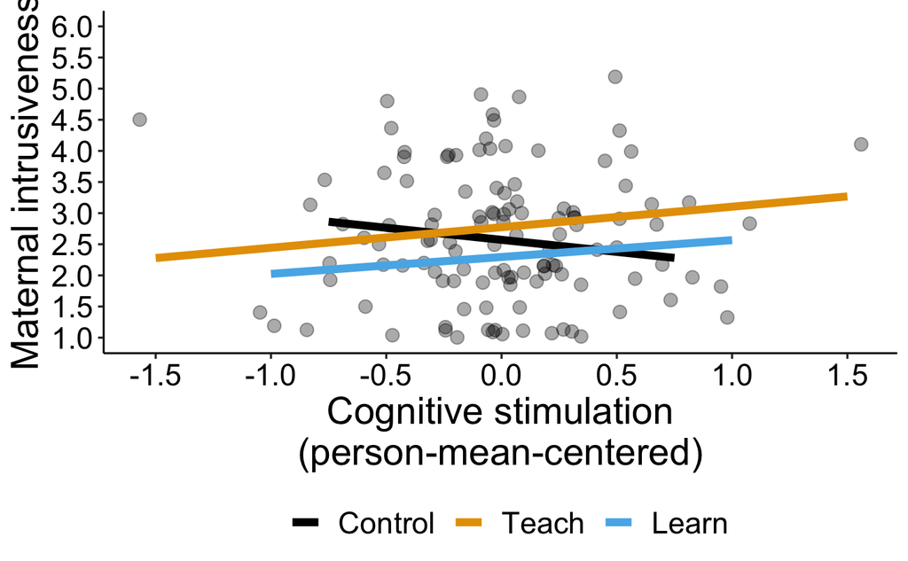

```r
da %>%
  mutate(
    group = recode_factor(
      group,
      "control" = "Control",
      "teach" = "Teach",
      "learn" = "Learn"
    )
  ) %>%
  ggplot(aes(stim_FP_pc, intrus_FP, color = group)) +
  geom_jitter(size = 3, alpha = 1/3, color = "black") +
  geom_smooth(method = "lm", size = 2, se = FALSE) +
  scale_y_continuous(breaks = seq.int(1, 7, .5), limits = c(1, 6)) +
  scale_x_continuous(breaks = seq.int(-2, 2, .5)) +
  scale_colour_manual(values=cbbPalette) +
  theme_pubr() +
  theme(
    strip.text = element_text(size = 16),
    axis.title.y = element_text(size = 20),
    axis.title.x = element_text(size = 20),
    axis.text.y = element_text(size = 16),
    axis.text.x = element_text(size = 16),
    legend.title = element_text(size = 18),
    legend.text = element_text(size = 16),
    legend.position = "bottom"
  ) +
  labs(
    x = "Cognitive stimulation\n(person-mean-centered)",
    y = "Maternal intrusiveness",
    color = NULL
  )

ggsave(
  "~/Box/lucy_king_files/BABIES/teach_learn/figures/stim_intrus.png",
  dpi = 600,
  width = 6,
  height = 5
)
```

```r
contrasts(da$group) = cbind( # reach group is baseline
  "control" = c(1, 0, 0),
  "learn" = c(0, 1, 0)
)

mlm_h_t_stim <-
  lmer(
    intrus_FP ~
      group * episode +
      stim_FP_mean +
      stim_FP_pc +
      (1|ID),
    data = da
  )
parameters(mlm_h_t_stim, standardize = "refit")
```

```
Parameter                 | Coefficient |   SE |         95% CI | t(118) |      p
---------------------------------------------------------------------------------
(Intercept)               |        0.26 | 0.20 | [-0.13,  0.65] |   1.31 | 0.190
group [control]           |       -0.25 | 0.28 | [-0.79,  0.30] |  -0.89 | 0.376
group [learn]             |       -0.53 | 0.28 | [-1.08,  0.01] |  -1.92 | 0.055
episode                   |        0.36 | 0.10 | [ 0.15,  0.56] |   3.44 | < .001
stim_FP_mean              |       -0.16 | 0.11 | [-0.39,  0.07] |  -1.39 | 0.164
stim_FP_pc                |       -0.08 | 0.06 | [-0.20,  0.05] |  -1.22 | 0.221
group [control] * episode |       -0.37 | 0.15 | [-0.66, -0.07] |  -2.46 | 0.014
group [learn] * episode   |       -0.54 | 0.15 | [-0.84, -0.24] |  -3.51 | < .001
```

##### In teach group only

```r
da_teach <-
  da %>%
  filter(group == "teach")

mlm_h_stim_teach <-
  lmer(
    intrus_FP ~
      episode_f +
      stim_FP_mean +
      stim_FP_pc +
      (1|ID),
    data = da
  )
anova(mlm_h_stim_teach)
parameters(mlm_h_stim_teach, standardize = "refit")
performance(mlm_h_stim_teach)
```

#### Warmth

```r
contrasts(da$group) = cbind( # control group is baseline
  "learn" = c(0, 1, 0),
  "teach" = c(0, 0, 1)
)

mlm_h_c_posreg <-
  lmer(
    intrus_FP ~
      group * episode_f +
      posreg_FP_mean +
      posreg_FP_pc +
      (1|ID),
    data = da
  )
anova(mlm_h_c_posreg)
parameters(mlm_h_c_posreg, standardize = "refit")
performance(mlm_h_c_posreg)
```

```r
contrasts(da$group) = cbind( # learn group is baseline
  "control" = c(1, 0, 0),
  "teach" = c(0, 0, 1)
)

mlm_h_l_posreg <-
  lmer(
    intrus_FP ~
      group * episode +
      posreg_FP_mean +
      posreg_FP_pc +
      (1|ID),
    data = da
  )
parameters(mlm_h_l_posreg, standardize = "refit")
```

```r
contrasts(da$group) = cbind( # reach group is baseline
  "control" = c(1, 0, 0),
  "learn" = c(0, 1, 0)
)

mlm_h_t_posreg <-
  lmer(
    intrus_FP ~
      group * episode +
      posreg_FP_mean +
      posreg_FP_pc +
      (1|ID),
    data = da
  )
parameters(mlm_h_t_posreg, standardize = "refit")
```

#### Visualize

```r
da %>%
  mutate(
    group = recode_factor(
      group,
      "control" = "Control",
      "teach" = "Teach",
      "learn" = "Learn"
    )
  ) %>%
  ggplot(aes(posreg_FP_pc, intrus_FP, color = group)) +
  geom_jitter(size = 3, psych::alpha = 1/3, color = "black") +
  geom_smooth(method = "lm", size = 2, se = FALSE) +
  scale_y_continuous(breaks = seq.int(1, 7, .5), limits = c(1, 6)) +
  scale_x_continuous(breaks = seq.int(-2, 2, .5)) +
  scale_colour_manual(values=cbbPalette) +
  theme_pubr() +
  theme(
    strip.text = element_text(size = 16),
    axis.title.y = element_text(size = 20),
    axis.title.x = element_text(size = 20),
    axis.text.y = element_text(size = 16),
    axis.text.x = element_text(size = 16),
    legend.title = element_text(size = 18),
    legend.text = element_text(size = 16),
    legend.position = "bottom"
  ) +
  labs(
    x = "Positve regard\n(person-mean-centered)",
    y = "Maternal intrusiveness",
    color = NULL
  )

ggsave(
  "~/Box/lucy_king_files/BABIES/teach_learn/figures/posreg_intrus.png",
  dpi = 600,
  width = 6,
  height = 5
)
```